# 35507071_TaskC_EDA

Wanting Echo Zhao

30 May, 2026

```r
# Load necessary packages
library(tidyverse)
library(dplyr)
library(tidyr)
library(ggplot2)
library(lubridate)
library(stringr)
library(naniar)
library(data.table)
library(gt)

prop <- read_csv("TaskC_property_victoria.csv")

# overview the data
cat("row: ", nrow(prop), "column:", ncol(prop))
```

```
## row:  418390 column: 12
```

```r
# see the type of each attribute
str(prop)
```

```
## spc_tbl_ [418,390 × 12] (S3: spec_tbl_df/tbl_df/tbl/data.frame)
##  $ ID           : num [1:418390] 1.28e+08 1.23e+08 2.02e+08 2.03e+08 1.40e+08 ...
##  $ postcode     : num [1:418390] 3095 3074 3978 3753 3197 ...
##  $ suburb       : chr [1:418390] "Eltham" "Thomastown" "Clyde North" "Beveridge" ...
##  $ sold_time    : Date[1:418390], format: "2018-07-04" "2016-07-16" ...
##  $ sold_price   : num [1:418390] 1900000 424000 309000 NA 901000 385000 710000 NA 425000 650000 ...
##  $ address      : chr [1:418390] "10 Sweeneys Lane, Eltham, Vic 3095" "2 Banksia Avenue, Thomastown, Vic 3074" "74 Yeungroon Boulevard, Clyde North, Vic 3978" "Lot 730, Radiata Street, Beveridge, Vic 3753" ...
##  $ beds         : num [1:418390] 7 3 NA NA 3 1 3 3 1 3 ...
##  $ baths        : num [1:418390] 4 1 NA NA 1 1 2 2 1 2 ...
##  $ parking      : num [1:418390] 2 2 NA NA 3 1 2 3 1 1 ...
##  $ area         : num [1:418390] 4322 659 448 325 638 ...
##  $ property_type: chr [1:418390] "house" "house" "residential-land" "residential-land" ...
##  $ description  : chr [1:418390] "Set in around 4323 m2 of rolling lawns surrounded by gardens landscaped by Ben Harris, this is family living on"| __truncated__ "AUCTION THIS SATURDAY AT 1PM<br/>Perfectly located in the popular and much sought after Thomastown West locale "| __truncated__ "Locat…
##  - attr(*, "spec")=
##   .. cols(
##   ..   ID = col_double(),
##   ..   postcode = col_double(),
##   ..   suburb = col_character(),
##   ..   sold_time = col_date(format = ""),
##   ..   sold_price = col_double(),
##   ..   address = col_character(),
##   ..   beds = col_double(),
##   ..   baths = col_double(),
##   ..   parking = col_double(),
##   ..   area = col_double(),
##   ..   property_type = col_character(),
##   ..   description = col_character()
##   .. )
##  - attr(*, "problems")=<externalptr>
```

# Question 1: Top 3 suburbs by transaction count + monthly 2022 plot

## **Mind map**

- Find the three suburbs with the highest number of transactions *across all years*.
- Then plot the monthly transaction counts during 2022 for those suburbs.
- If *Toorak* is not already in the top three, include it as a fourth line on the plot.

```r
# Compute NA value
miss_var_cumsum(prop)
```

```
## # A tibble: 12 × 3
##    variable      n_miss n_miss_cumsum
##    <chr>          <int>         <int>
##  1 ID                21            21
##  2 postcode          21            42
##  3 suburb            21            63
##  4 sold_time       5218          5281
##  5 sold_price     50425         55706
##  6 address         6158         61864
##  7 beds           19884         81748
##  8 baths          19884        101632
##  9 parking        19884        121516
## 10 area              28        121544
## 11 property_type     21        121565
## 12 description       26        121591
```

```r
# There is 21   miss data in `suburb`

# Find the top 3 suburbs by transaction count
prop_clean <- prop |>
  filter(!is.na(suburb))

# Compute the count of transactions of each suburb, then sort descently. sclice top 3
sub_count <- prop_clean |>
  count(suburb, sort = TRUE, name = "transation_count")

# show top 10
head(sub_count, 10)
```

```
## # A tibble: 10 × 2
##    suburb      transation_count
##    <chr>                  <int>
##  1 Toorak                  3818
##  2 Melbourne               3556
##  3 Clyde North             2090
##  4 Mornington              2031
##  5 Prahran                 2031
##  6 Preston                 2025
##  7 Tarneit                 2023
##  8 Officer                 2022
##  9 Sunbury                 2011
## 10 Truganina               2008
```

```r
# Top 1 is Toorak, so there is no need to add it individually for question 1
# extract top 3
top3 <- sub_count$suburb[1:3]
top3
```

```
## [1] "Toorak"      "Melbourne"   "Clyde North"
```

The top three suburbs are **Toorak (3,818), Melbourne (3,556), and Clyde North (2,090)**. Toorak is already #1, so the plot below contains exactly those three lines (no extra Toorak line is needed).

```r
# Build a (suburb + month) count table for 2022 only.

monthly_2022 <- prop_clean |>
  filter(year(sold_time) == 2022,
         suburb %in% top3) |>
  count(suburb, month = month(sold_time), name = "transation_counts") |>
  arrange(suburb, month)

# Transfer long to wide format
monthly_2022 |>
  pivot_wider(names_from = month, values_from = transation_counts)
```

```
## # A tibble: 3 × 13
##   suburb   `1`   `2`   `3`   `4`   `5`   `6`   `7`   `8`   `9`  `10`  `11`  `12`
##   <chr>  <int> <int> <int> <int> <int> <int> <int> <int> <int> <int> <int> <int>
## 1 Clyde…    32    52    59    37    54    36    34    70    31    40    28    16
## 2 Melbo…    34    38    46    43    36    40    31    29    35    47    35    40
## 3 Toorak    20    24    35    30    44    26    18    32    34    20    38    NA
```

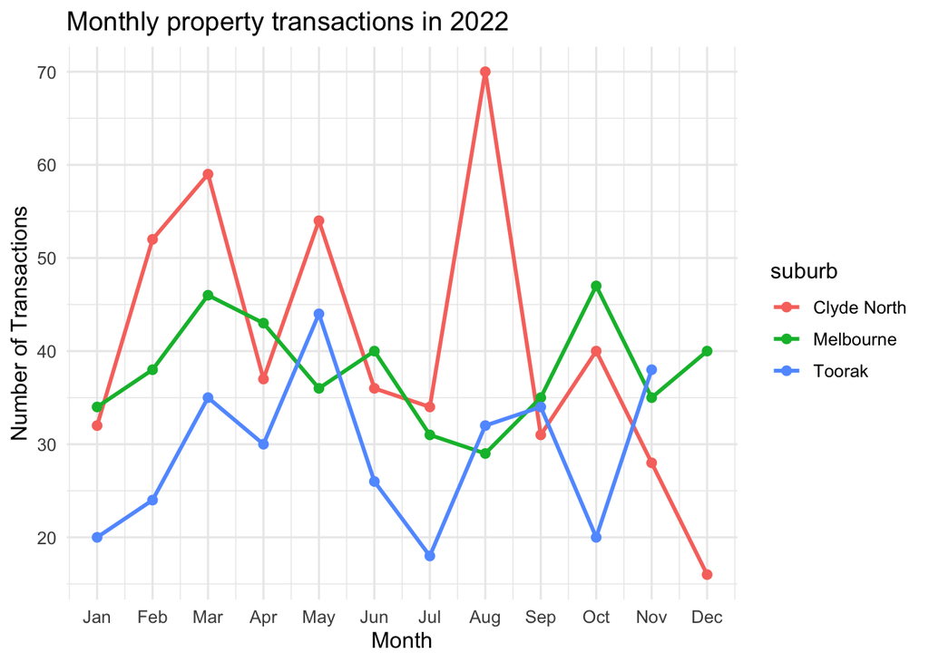

```r
# Plot it
ggplot(monthly_2022, aes(x = month, y = transation_counts, colour = suburb, group = suburb)) +
  geom_line(linewidth = 1) +
  geom_point(size = 2) +
  scale_x_continuous(breaks = 1:12, labels = month.abb) +  # 12 months and show as abbr, saving space and looks tidier.
  labs(title = "Monthly property transactions in 2022",
       x = "Month",
       y = "Number of Transactions") +
  theme_minimal(base_size = 12)
```

## **Interpretation of plot**

Clyde North peaks in August 2022 (70 transactions), the biggest single suburb-month in the chart, before falling sharply at the end of year. Melbourne is the steadiest of the three. Toorak shows the lowest volume of the three and has **zero** December 2022 transactions — likely a data-collection gap rather than a market collapse.

# Question 2: The 3 most important keywords in `description` impacting price

```r
library(Matrix)   # sparse document-term matrix
library(glmnet)   # LASSO

# STEP1: 10% random sample, keeping only rows with a price and a description.
set.seed(123)
samp <- prop |>
  filter(!is.na(sold_price), !is.na(description)) |>
  slice_sample(prop = 0.1)

cat("Sample size:", nrow(samp), "rows\n")
```

```
## Sample size: 36796 rows
```

```r
# Having a look at the top 10 row of sample$desription,
# Figure out what kind of messy should we clean
# head(samp$description, 10)

# STEP2: Clean the description text:
clean_text <- samp$description |>
  str_replace_all("<[^>]+>", " ") |> # strip HTML tags like <br/>
  str_to_lower() |>  # lawer case
  str_replace_all("[^a-z ]+"," ") |>  # keep pure letters. Drop all numbers
  str_squish()  # collapse multiple space, so later easier to split text.
```

> Reference: [Week 6](https://learning.monash.edu/course/view.php?id=41099&section=28) Map-reduce - [data table](https://cran.r-project.org/web/packages/data.table/vignettes/datatable-intro.html)

```r
# STEP3: Tokenise and explode into a long (doc, term) table using data.table
# a 10% sample is still ~37k docs and 28k+ unique terms).
tokens <- str_split(clean_text, " ")
dtm_long <- data.table(doc  = rep(seq_along(tokens), lengths(tokens)),
                       term = unlist(tokens))

# STEP4: Remove various stopword

# 1) Grab general English stopwords (Snowball is a reliable, standard lexicon)
general_stopwords <- stopwords::stopwords(language = "en", source = "snowball")

# 2) Define your specific technical and domain-specific noise sequences
html_leftovers <- c("amp", "br", "lt", "gt", "quot", "apos")

real_estate_terms <- c(
  "also", "new", "one", "two", "three", "four", "five",
  "feature", "features", "property", "home", "house", "bed", "bedroom", "bedrooms",
  "bath", "bathroom", "bathrooms", "room", "rooms", "living", "please", "including",
  "call", "inspection", "view", "contact", "auction", "sale"
)

# 3) Combine them into a single, deduplicated vector
stopwords_en <- unique(c(general_stopwords, html_leftovers, real_estate_terms))

# 4) Filter the data.table
dtm_long <- dtm_long[term != "" & nchar(term) >= 3]
dtm_long <- dtm_long[!term %in% stopwords_en]

nrow(dtm_long)  # 4029090
```

```
## [1] 4029090
```

```r
# STEP5: Vocabulary filter: keep only terms that appear in at least 1% of docs.
# Filter: Rare/unique words make the model unstable; very common words don't help either.
min_df <- ceiling(0.01 * nrow(samp))
keep_terms <- dtm_long[, .(df = uniqueN(doc)), by = term][df >= min_df, term]
dtm_long <- dtm_long[term %in% keep_terms]
dtm_long <- unique(dtm_long, by = c("doc", "term"))   # collapse to PRESENCE
cat("Vocabulary size after filtering:", length(keep_terms), "terms\n")
```

```
## Vocabulary size after filtering: 1500 terms
```

```r
# STEP6: Build the sparse document-term matrix
term_levels <- sort(unique(dtm_long$term))
dtm <- sparseMatrix(
  i = dtm_long$doc,
  j = match(dtm_long$term, term_levels),
  x = 1,
  dims = c(nrow(samp), length(term_levels)),
  dimnames = list(NULL, term_levels)
)
dim(dtm)
```

```
## [1] 36796  1500
```

```r
# 7) Fit LASSO with cross-validated lambda.
y <- log(samp$sold_price)
fit <- cv.glmnet(dtm, y, alpha = 1, nfolds = 5)

# Pull non-zero coefficients at lambda.1se (the more conservative pick:
# the largest lambda whose error is within 1 SE of the minimum).
co <- coef(fit, s = "lambda.1se")
coef_tbl <- tibble(term = rownames(co)[-1],          # drop intercept
                   coef = as.numeric(co)[-1]) |>
  filter(coef != 0) |>
  arrange(desc(abs(coef)))

# Top 20 for context, then the answer (top 3)
head(coef_tbl, 20)
```

```
## # A tibble: 20 × 2
##    term         coef
##    <chr>       <dbl>
##  1 toorak      0.289
##  2 apartment  -0.259
##  3 melton     -0.208
##  4 acres       0.200
##  5 hydronic    0.192
##  6 camberwell  0.182
##  7 marble      0.153
##  8 cellar      0.150
##  9 fireplaces  0.145
## 10 communal   -0.136
## 11 doncaster   0.132
## 12 miele       0.130
## 13 stca        0.128
## 14 ofp         0.126
## 15 townhouses  0.121
## 16 victorian   0.120
## 17 butler      0.120
## 18 affordable -0.119
## 19 frankston  -0.117
## 20 period      0.111
```

```r
top3_keywords <- head(coef_tbl, 3)
top3_keywords
```

```
## # A tibble: 3 × 2
##   term        coef
##   <chr>      <dbl>
## 1 toorak     0.289
## 2 apartment -0.259
## 3 melton    -0.208
```

[LASSO](https://www.r-bloggers.com/2020/05/quick-tutorial-on-lasso-regression-with-example/)

## **Answer**

The three keywords with the highest coefficients are: `toorak` (coef: 0.288), `appartment`(coef: -0.259), `melton`(coef: -0.208)

## **Insights**

Some of the top words (`toorak`, `camberwell`,`melton`) are *suburb names*. They function as legitimate description keywords, but they partly proxy for the suburb itself. The other items in the Some keywords in top 20, such as `marble`, `cellar`, `fireplaces`, `hydronic`, `victorian`, `miele`, correspond more directly to property *features* and align human’s intuition that luxury fittings drive prices up. This also can be tell by words like `communal`, `affordable` with negative coefficient, which indicating that the presence of these words suggests lower property prices.

# Question 3: Correlation of price and land size by (top-3 suburb × property type)

## **Mind map**

- Get each suburb among the top 3 suburbs identified in Q1 - Extract specific columns
- sold_price and area - `sold_price` remove NA - `area` remove minus value and NA. so I filter on `area > 0` (this drops both `NA` and `-1`).
- `for each suburb` and `for each property type` suggest `group`.

Because small sample sizes (like only 2 observations) artificially force a perfect correlation of, flagging low n_obs helps readers know which results are reliable and which are misleading.

> obs: www.wisdomlib.org. (2025, August 18). Number of observations: Significance and symbolism. https://www.wisdomlib.org/concept/number-of-observations

```r
top3_suburbs <- c("Toorak", "Melbourne", "Clyde North")
types_wanted <- c("house", "unit", "townhouse", "apartment")

prop_q3 <- prop |>
  filter(suburb %in% top3_suburbs,
         property_type %in% types_wanted,
         !is.na(sold_price),
         !is.na(area), area > 0)

# How many suburb and property
prop_q3 |>
  count(suburb, property_type) |>
  pivot_wider(names_from = property_type, values_from = n, values_fill = 0)
```

```
## # A tibble: 3 × 5
##   suburb      house townhouse  unit apartment
##   <chr>       <int>     <int> <int>     <int>
## 1 Clyde North   808        43     1         0
## 2 Melbourne       0         0     2       139
## 3 Toorak        334         9     0        11
```

```r
# Compute the correlation per group
cor_tbl <- prop_q3 |>
  group_by(suburb, property_type) |>
  summarise(n_obs = n(),
            correlation = if(n() >= 2) cor(sold_price, area) else NA_real_,
            .groups = "drop") |>
  filter(!is.na(correlation)) |>
  arrange(suburb, property_type)

cor_tbl
```

```
## # A tibble: 7 × 4
##   suburb      property_type n_obs correlation
##   <chr>       <chr>         <int>       <dbl>
## 1 Clyde North house           808      0.323
## 2 Clyde North townhouse        43      0.483
## 3 Melbourne   apartment       139      0.0761
## 4 Melbourne   unit              2      1
## 5 Toorak      apartment        11      0.899
## 6 Toorak      house           334      0.706
## 7 Toorak      townhouse         9      0.391
```

## **Findings**

Cells with reasonable sample sizes(`n_obs`):

- **Toorak / house** (n = 334, r ≈ 0.71): strong positive — in this suburb, bigger land translates into substantially higher prices.
- **Clyde North / house** (n = 808, r ≈ 0.32): moderate positive — outer-suburb new builds, where land matters but standardised house specs flatten the relationship somewhat.
- **Melbourne / apartment** (n = 139, r ≈ 0.08): essentially no relationship — for inner-city apartments, location, floor, and finishes dominate; the recorded land area is barely informative.

Cells with very few observations — **Melbourne / unit (n = 2)**, **Toorak / townhouse (n = 9)**, **Toorak / apartment (n = 11)** are kept for completeness but should be read with caution; r = 1 for Melbourne / unit is a mathematical artefact of having only two data points, not a meaningful finding.

> *Note: There are no `apartment` recorded in `Clyde North`, 0 `house` and `townhouse` in Melbourn,and non `unit` in Toorak.*

# Question 4: Top 5 capital gains (resold within 5 years)

## **Mind Map**

- `Which properties` means lock `property_type`
- `highest price increases`, as far as I understand, there are two ways to measure. One is to compare the price increase by the gap between first sold_price and its maximum value. Second is to compare popular.
- `exclude properties where the time between the first and last sale exceeds five years.` means mutate a new column, computing the duration, filter ones exceed 5.
- `List the top five`: Sort and
- `address, capital gain, and the duration between the first and last sale.`: select these columns.

## **Challenges** and **Solutions**

1. Only `sold_time`, the `ID` is transaction number instead of identity of each property. property with same postcode and address should be same one, and they can be encode with a new “ID”. The reason of why using “address + postcode” as key, even address include postcode is to uniquely identify properties safely, in case there are typo.
2. Extreme value handling. In order to avoid impaction by outliers. control the range of `sold_price`

```r
head(sort(prop$sold_price),5)
```

```
## [1]   1   1   1   1 270
```

```r
tail(sort(prop$sold_price),5)
```

```
## [1]   32000000   80000088   80000088  320000000 1010000000
```

Using chunk above you can notice the minimum price would be 1 and the top two ($1.01B and $320M) are implausible. I therefore restrict to prices in the range **$50,000 ≤ sold_price ≤ $50,000,000** before computing capital gains. This keeps the genuine premium Toorak sales (up to ≈$32M) while removing the obvious typos.

```r
# 1) Filter to rows with valid address, plausible price, and valid date.
ok <- prop |>
  filter(!is.na(address), address != "",
         !is.na(sold_price), sold_price >= 50000, sold_price <= 50e6,
         !is.na(sold_time))

# 2) Synthesis filtered properties using data.table.

ok_dt <- as.data.table(ok)

per_property <- ok_dt[, .(
  n_sales     = .N,
  first_date  = min(sold_time),    # column first_date
  last_date   = max(sold_time),    # column last_date
  first_price = sold_price[which.min(sold_time)],    # column first_price
  last_price  = sold_price[which.max(sold_time)]     # column last_price
), by = .(address, postcode)    # double insurance - filter the same property
][n_sales >= 2 & last_date > first_date]   # at least two different-day sales

# 3) Derive capital gain and duration in years
per_property$gain <- per_property$last_price - per_property$first_price
per_property$duration_years <- as.numeric(per_property$last_date - per_property$first_date) / 365

# 4) Apply the ≤ 5-year filter and pick the top 5

top5_q4 <- per_property |>
  as_tibble() |>   # output should be a table
  filter(duration_years <= 5) |>
  arrange(desc(gain)) |>
  slice_head( n = 5 ) |>
  mutate(duration_years = round(duration_years,2)) |>
  select(address, gain, duration_years,
         first_date, first_price, last_date, last_price)

top5_q4
```

```
## # A tibble: 5 × 7
##   address       gain duration_years first_date first_price last_date  last_price
##   <chr>        <dbl>          <dbl> <date>           <dbl> <date>          <dbl>
## 1 9 Whernsid… 1.10e7           4.35 2016-11-08    11000000 2021-03-13   22000000
## 2 33 Grandvi… 6.68e6           4.08 2016-09-19     9320000 2020-10-17   16000000
## 3 4 Woorigol… 5.43e6           1.48 2014-05-03     3075000 2015-10-26    8500000
## 4 6-8 Glenis… 5.09e6           2.35 2019-12-17     2510000 2022-04-21    7600000
## 5 8 Jamieson… 5   e6           4.18 2011-05-16     1100000 2015-07-18    6100000
```

## **Answer**

Table

# Question 5: Properties that could not realistically exist

## **Mindmap**

- Removing negative values from area.

```r
# Drop negative area values per the spec. (NA area is allowed to stay —
# the instruction only says to remove *negative* values.)
prop_q5 <- prop |> filter(is.na(area) | area >= 0)
cat("Rows after removing negative area:", nrow(prop_q5), "\n")
```

```
## Rows after removing negative area: 191168
```

## Implausible senarios

```r
# 1) Tiny area for a multi-bedroom
row1 <- prop_q5 |>
  filter(area>=1, area <=3, beds >= 3) |>
  select(ID, address, beds, baths, parking, area, property_type) |>
  head(1)
```

```r
# 2) Implausibly large parking space
row2 <- prop_q5 |>
  filter(parking >= 100) |>
  select(ID, address, beds, baths, parking, area, property_type) |>
  arrange(desc(parking)) |>
  head(1)
```

```r
# 3) Implausibly large bedroom counts in a single house
row3 <- prop_q5 |>
  filter(beds >= 20) |>
  select(ID, address, beds, baths, parking, area, property_type) |>
  arrange(desc(beds)) |>
  head(1)
```

```r
# 4) Implausibly large bathroom counts in a single house
row4 <- prop_q5 |>
  filter(baths >= 18, area <= 5) |>
  select(ID, address, beds, baths, parking, area, property_type) |>
  arrange(desc(baths)) |>
  head(1)
```

```r
# 5) Implausibly large bathroom counts more than bedroom
row5 <- prop_q5 |>
  filter(beds == 0, baths >= 3) |>
  select(ID, address, beds, baths, parking, area, property_type) |>
  arrange(desc(baths)) |>
  head(1)
```

```r
implusiable_table <- bind_rows(row1, row2, row3, row4, row5)

#  use `implusiable_table` to generate a final table like assignment requires
summary_table <- implusiable_table |>
  mutate(
    Feature = c("area", "parking", "beds", "baths", "beds + baths"),
    Reason  = c(
      "A house on ~1 m2 of land cannot physically hold 3+ bedrooms.",
      "11,951 parking spaces for a suburban house (next-highest in the data is 200).",
      "30 bedrooms in a single house; the address field is also corrupted.",
      "20 bathrooms recorded on a property of only ~1 m2 of land.",
      "0 bedrooms but 3+ bathrooms - impossible for a residential house."
    )
  ) |>
  select(Feature, Reason, Address = address, `Property ID` = ID)

knitr::kable(summary_table)   # renders as a proper table in the knit
```

| Feature | Reason | Address | Property ID |
| --- | --- | --- | --- |
| area | A house on ~1 m2 of land cannot physically hold 3+ bedrooms. | 37 Beatties Road, Koo Wee Rup, Vic 3981 | 107405202 |
| parking | 11,951 parking spaces for a suburban house (next-highest in the data is 200). | 50 Beverley Road, McCrae, Vic 3938 | 126712114 |
| beds | 30 bedrooms in a single house; the address field is also corrupted. | 83 Bedrooms, 34 Bathrooms, Burwood, Vic 3125 | 118443975 |
| baths | 20 bathrooms recorded on a property of only ~1 m2 of land. | 18 Park Road, Warburton, Vic 3799 | 124748374 |
| beds + baths | 0 bedrooms but 3+ bathrooms - impossible for a residential house. | 38 Fitzwilliam Drive, Doreen, Vic 3754 | 132715294 |